# Human Disease Blood Atlas Olink Data Quality Control

- Show All Code
- Hide All Code
- View Source

Phase 2 (Olink HT) - Batch 4

Author

María Bueno Álvez

Published

2025-04-28

# 1 Data overview

This section provides an **overview of the Olink dataset**, including the total number of samples and proteins measured.

In the delivered Olink dataset, there are currently **2018 samples**, and **5416 proteins** measured in each sample.

**Figure 1**: Number of samples per cohort.

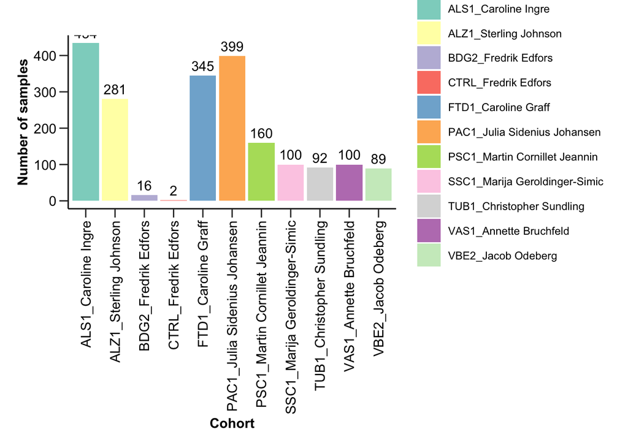

```r
data_hdba |>
  filter(!SampleType %in% control_sample_types) |>
  distinct(DAid) |>
  left_join(manifest, by = "DAid") |>
  mutate(Cohort = paste(Cohort, `PI - sample owner`, sep = "_")) |>
  count(Cohort) |>
  ggplot(aes(Cohort, n, fill = Cohort)) +
  geom_col() +
    scale_fill_manual(values = brewer.pal(n = 11, name = "Set3")) +
  geom_text(aes(label = n), vjust = -0.5) +
  theme_hpa(angled = T) +
  ylab("Number of samples")
```

```r
#ggsave(savepath("da_phase2_cohorts.png"), h = 6, w = 6)
```

**Figure 2**: Sample distribution across plates.

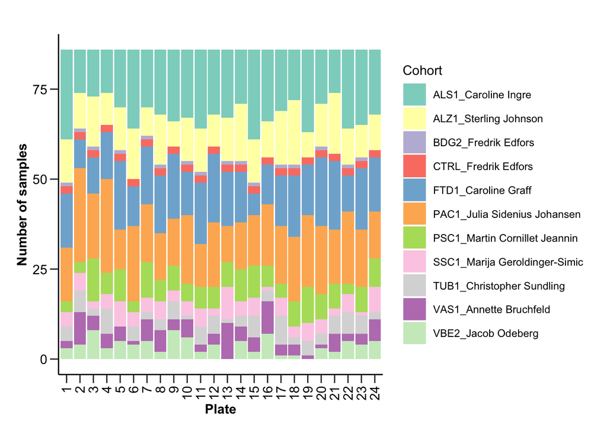

```r
data_hdba |>
  mutate(Plate = gsub("P", "", Plate),
         Plate = as.numeric(Plate),
         Plate = as.factor(Plate)) |>
  distinct(DAid, SampleID, Plate, SampleType) |>
  filter(!is.na(Plate)) |>
  left_join(manifest, by = "DAid") |>
  mutate(Cohort = paste(Cohort, `PI - sample owner`, sep = "_"),
         Cohort = ifelse(SampleType %in% control_sample_types, "CONTROLS", Cohort))  |>
  group_by(Plate, Cohort) |>
  count() |>
  ggplot(aes(Plate, n, fill = Cohort)) +
  geom_col() +
  scale_fill_manual(values = brewer.pal(n = 11, name = "Set3")) +
  theme_hpa(angled = T) +
  ylab("Number of samples")
```

```r
#ggsave(savepath("da_phase2_plates.png"), h = 6, w = 8)
```

# 2 Step 1: Exploration of control samples and control assays

This section identifies and **analyzes control samples to ensure data quality**. Specifically, we explore correlations between technical replicates for selected patients (patient 2 and patient 3) across multiple plates.

## 2.1 Plate-to-plate correlation for patient 2 & 3

We calculate **Spearman correlations for measurements of Patient 2 and Patient 3 across plates**. These analyses help assess technical reproducibility.

**Figure 3**: Correlation heatmap for Patient 2 across plates.

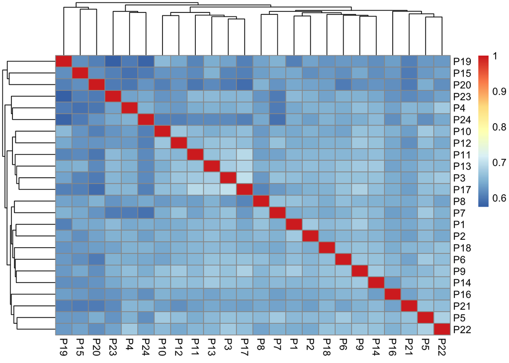

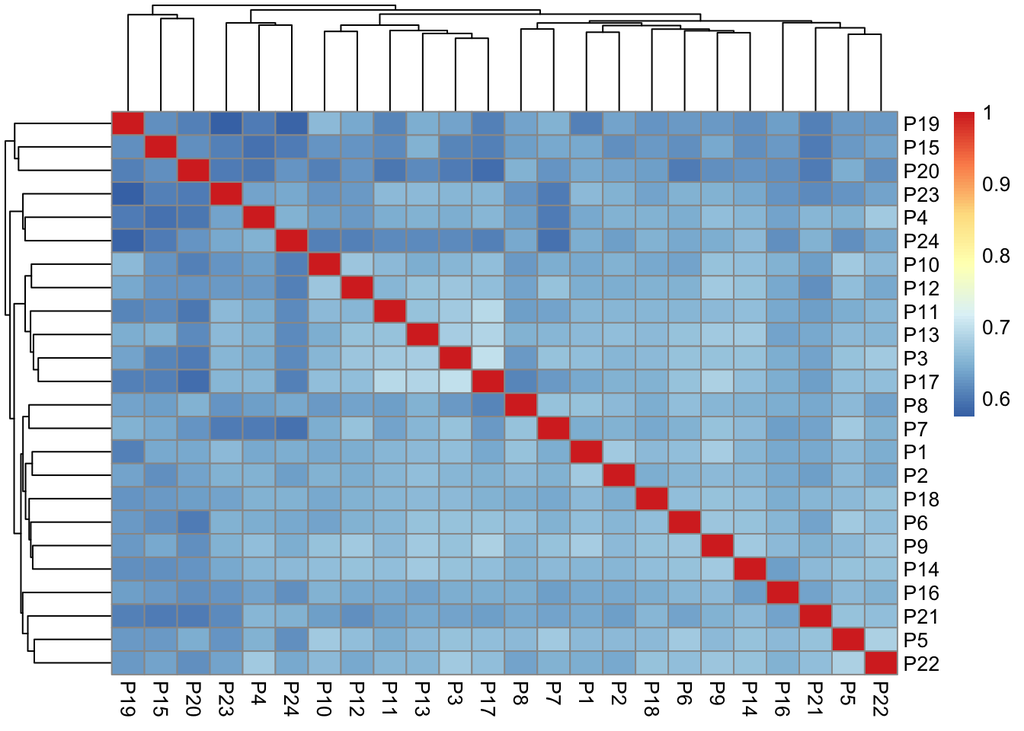

```r
data_ht |>
  left_join(id_mapping, by = "SampleID") |>
  filter(DAid == "DA12362") |>
  select(Plate, OlinkID, PCNormalizedNPX) |>
  pivot_wider(names_from = OlinkID, values_from = PCNormalizedNPX) |>
  column_to_rownames("Plate") |>
  t() |>
  cor(method = "spearman")|>
  pheatmap()|>
  as.ggplot()
```

```r
#ggsave(savepath("p2_heatmap.png"), h = 8, w = 8)
```

**Figure 4**: Correlation heatmap for Patient 3 across plates.

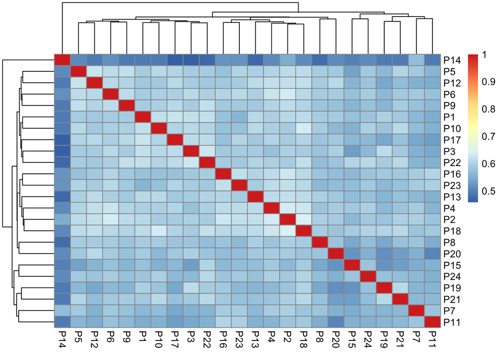

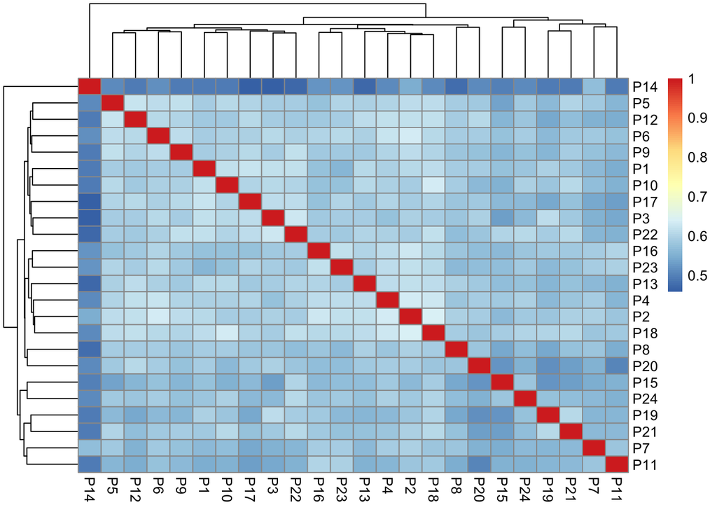

```r
data_ht |>
  left_join(id_mapping, by = "SampleID") |>
  filter(DAid == "DA12363") |>
  select(Plate, OlinkID, NPX) |>
  pivot_wider(names_from = OlinkID, values_from = NPX) |>
  column_to_rownames("Plate") |>
  t() |>
  cor(method = "spearman")|>
  pheatmap() |>
  as.ggplot()
```

```r
#ggsave(savepath("p3_heatmap.png"), h = 8, w = 8)
```

**Figure 5**: Scatterplots showing pairwise correlations between plates for Patient 2.

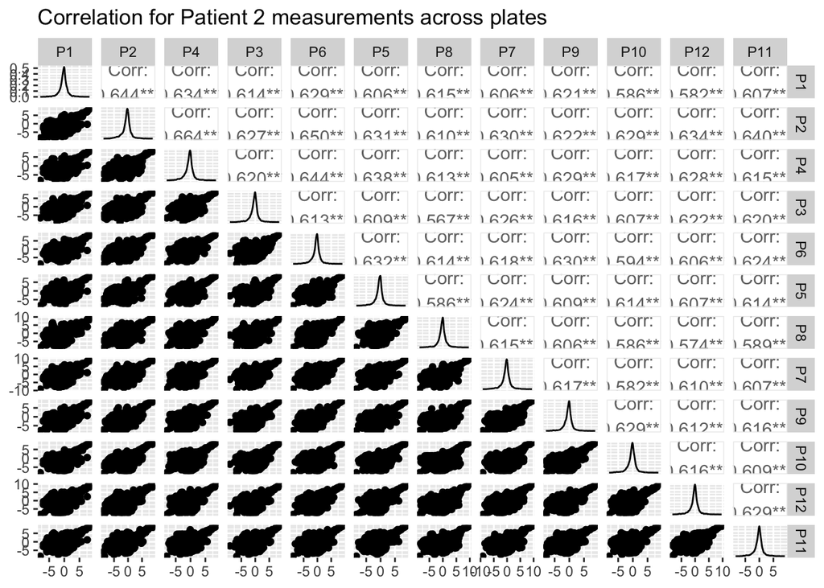

```r
data_ht |>
  left_join(id_mapping, by = "SampleID") |>
  filter(DAid == "DA12362") |>
  select(Plate, OlinkID, NPX) |>
  pivot_wider(names_from = Plate, values_from = NPX) |>
  ggpairs(c(2:13),
            lower = list(continuous = "points", size = 0.05)) +
  ggtitle("Correlation for Patient 2 measurements across plates")
```

```r
#ggsave(savepath("p2_plate_scatterplots.png"), h = 10, w = 10)
```

**Figure 6**: Scatterplots showing pairwise correlations between plates for Patient 3.

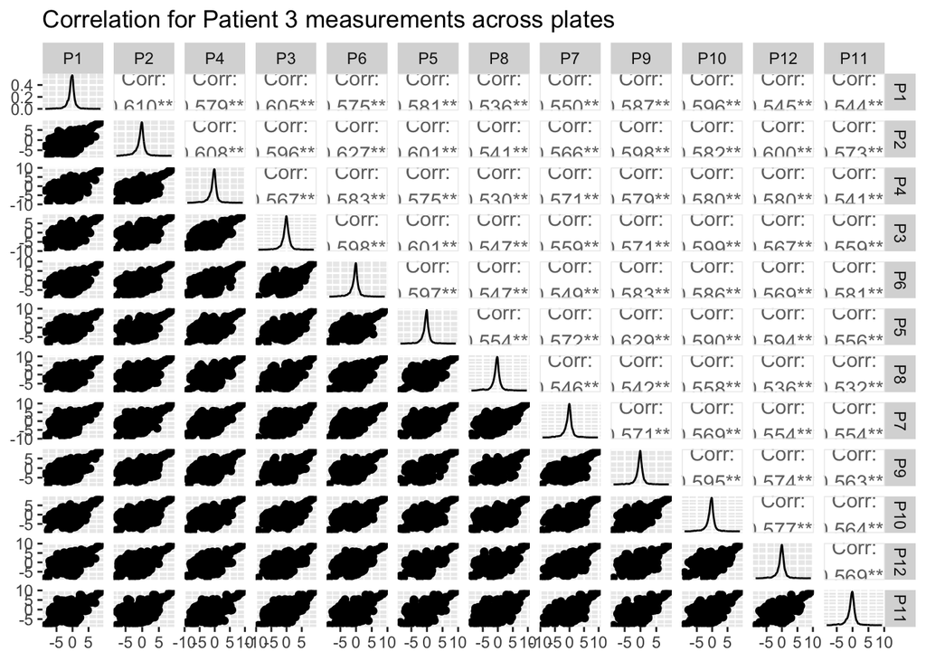

```r
data_ht |>
  left_join(id_mapping, by = "SampleID") |>
  filter(DAid == "DA12363") |>
  select(Plate, OlinkID, NPX) |>
  pivot_wider(names_from = Plate, values_from = NPX) |>
  ggpairs(c(2:13),
            lower = list(continuous = "points", size = 0.5)) +
  ggtitle("Correlation for Patient 3 measurements across plates")
```

```r
#ggsave(savepath("p3_plate_scatterplots.png"), h = 10, w = 10)
```

### 2.1.1 Correlation excluding proteins below LOD

This section refines the **correlation analysis by excluding proteins that fall below the LOD across all replicates**. This step ensures a cleaner analysis focusing only on reliably measured proteins.

```r
exclude_proteins <-
  data_ht_lod |>
  filter(DAid %in% control_samples) |>
  mutate(under_LOD = ifelse(NPX < LOD, "Yes", "No")) |>
  group_by(Assay) |>
  count(under_LOD) |>
  filter(under_LOD == "Yes") |>
  ungroup() |>
  filter(n > length(unique(data_ht$PlateID)))
```

**Figure 7**: Heatmaps of correlations for Patient 2 measurements (filtered for proteins above LOD).

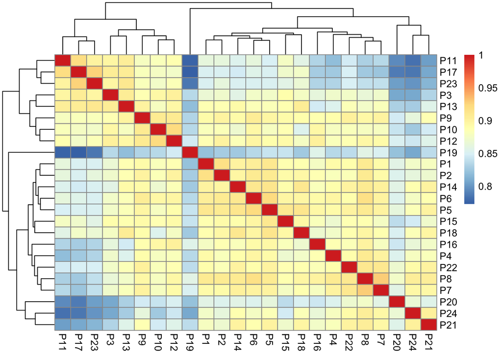

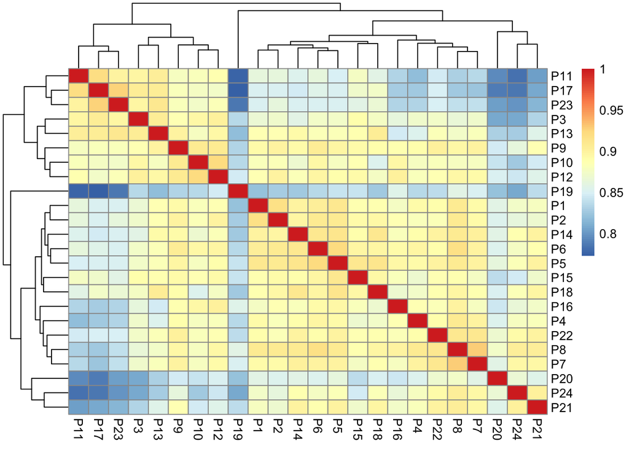

```r
data_ht |>
  left_join(id_mapping, by = "SampleID") |>
  filter(DAid == "DA12362",
         !Assay %in% exclude_proteins$Assay) |>
  select(Plate, OlinkID, PCNormalizedNPX) |>
  pivot_wider(names_from = OlinkID, values_from = PCNormalizedNPX) |>
  column_to_rownames("Plate") |>
  t() |>
  cor(method = "spearman")|>
  pheatmap() |>
  as.ggplot()
```

```r
#ggsave(savepath("p2_subset_heatmap.png"), h = 8, w = 8)
```

**Figure 8**: Heatmaps of correlations for Patient 3 measurements (filtered for proteins above LOD).

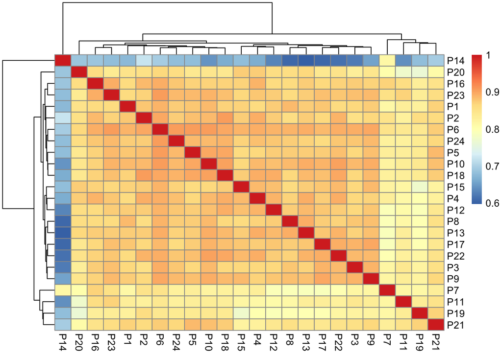

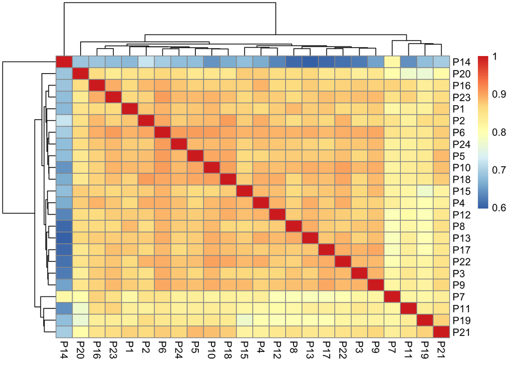

```r
data_ht |>
  left_join(id_mapping, by = "SampleID") |>
  filter(DAid == "DA12363",
         !Assay %in% exclude_proteins$Assay) |>
  select(Plate, OlinkID, NPX) |>
  pivot_wider(names_from = OlinkID, values_from = NPX) |>
  column_to_rownames("Plate") |>
  t() |>
  cor(method = "spearman")|>
  pheatmap() |>
  as.ggplot()
```

```r
#ggsave(savepath("p3_subset_heatmap.png"), h = 8, w = 8)
```

## 2.2 Remove control assays & samples

In this step, we **filter out control assays and samples** that are not part of the main dataset. This ensures clean data for downstream analyses.

```r
data_step_1 <-
  data_ht_lod |>
  filter(!SampleType %in% control_sample_types,
         !DAid %in% control_samples, # Remove internal KTH controls
         !AssayType %in% control_assay_types) |>
  select(DAid, Assay, OlinkID, UniProt, Panel, Block, Plate, Count, ExtNPX, NPX, PCNormalizedNPX, AssayQC, SampleQC, LOD) |>
  mutate(above_LOD = ifelse(NPX > LOD, "Yes", "No"))
```

# 3 Step 2: QC warnings

In this step, we assess **quality control (QC) warnings at the sample and protein levels**. Samples or protein measurements flagged with warnings will be excluded based on predefined thresholds.

## 3.1 Percentage of QC warnings per sample

We calculate the number of QC warnings per sample, with a focus on those that do not pass QC.

**Figure 9**: Barplot showing the number of QC warnings for each sample, colored by cohort.

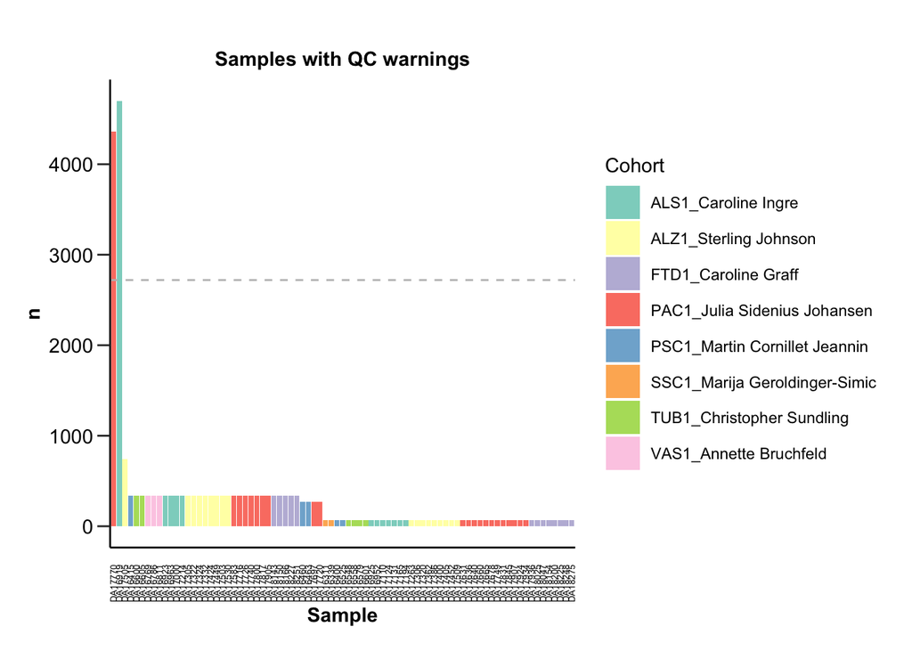

```r
data_step_1 |>
  group_by(DAid) |>
  count(SampleQC) |>
  filter(!SampleQC %in% c("NA", "PASS")) |>
  arrange(-n) |>
  left_join(manifest, by = "DAid") |>
  mutate(Cohort = paste(Cohort, `PI - sample owner`, sep = "_")) |>
  ggplot(aes(fct_reorder(DAid, -n), n, fill = Cohort)) +
  geom_col() +
  scale_fill_manual(values = brewer.pal(n = 11, name = "Set3")) +
  geom_hline(yintercept = 5440/2, linetype = "dashed", color = "grey") +
  theme_hpa(angled = T) +
  xlab("Sample") +
  theme(axis.text.x = element_text(size = 5),
        axis.ticks.x = element_blank()) +
  ggtitle("Samples with QC warnings")
```

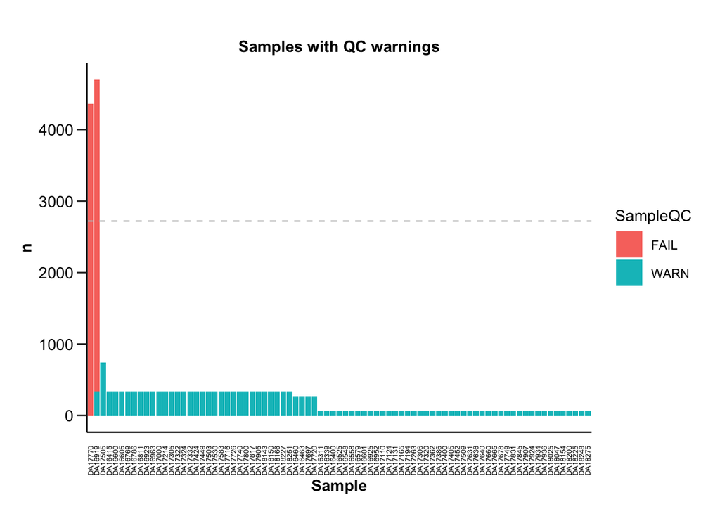

```r
#ggsave(savepath("samples_qc.png"), h = 4, w = 10)

data_step_1 |>
  group_by(DAid) |>
  count(SampleQC) |>
  filter(!SampleQC %in% c("NA", "PASS")) |>
  arrange(-n) |>
  left_join(manifest, by = "DAid") |>
  mutate(Cohort = paste(Cohort, `PI - sample owner`, sep = "_")) |>
  ggplot(aes(fct_reorder(DAid, -n), n, fill = SampleQC)) +
  geom_col() +
  geom_hline(yintercept = 5440/2, linetype = "dashed", color = "grey") +
  theme_hpa(angled = T) +
  xlab("Sample") +
  theme(axis.text.x = element_text(size = 5),
        axis.ticks.x = element_blank()) +
  ggtitle("Samples with QC warnings")
```

**Figure 10**: Beeswarm plot showing the number of proteins passing QC for each sample.

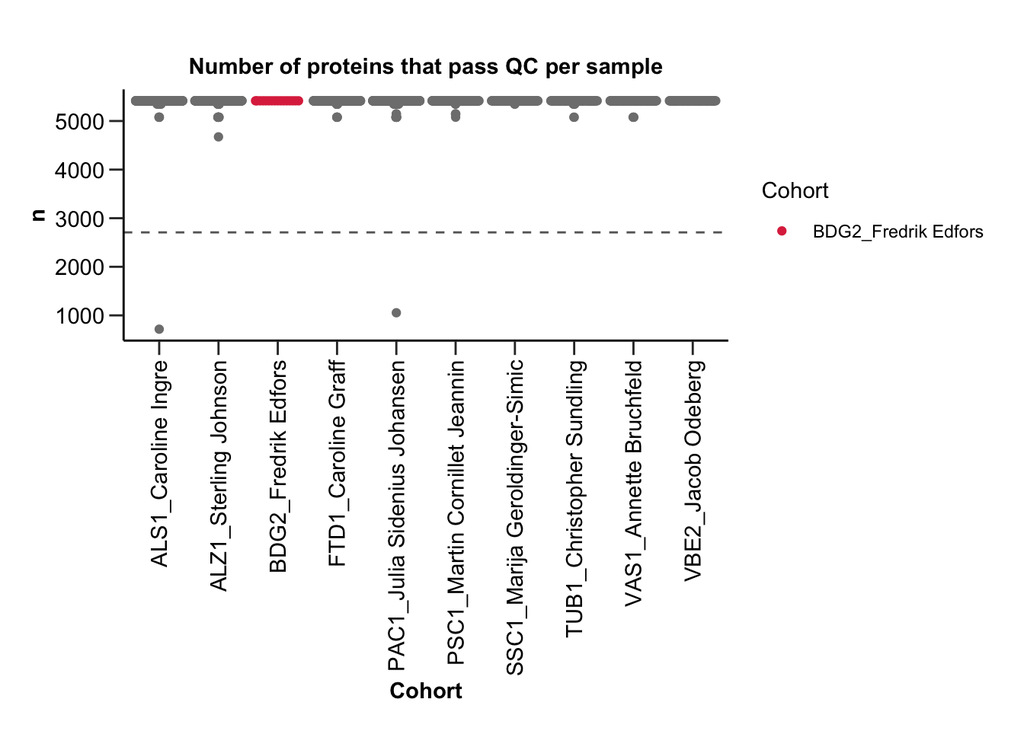

```r
data_step_1 |>
  group_by(DAid) |>
  filter(SampleQC == "PASS") |>
  count(SampleQC) |>
  left_join(manifest, by = "DAid") |>
  filter(Cohort != "CTRL") |>
  mutate(Cohort = paste(Cohort, `PI - sample owner`, sep = "_")) |>
  ggplot(aes(Cohort, n, color = Cohort)) +
  geom_quasirandom() +
  geom_hline(yintercept = n_proteins / 2, color = "grey40", linetype = "dashed") +
 # geom_text_repel(aes(label = DAid), show.legend = F) +
  scale_color_manual(values = pal_phase2) +
  theme_hpa(angled = T) +
  ggtitle("Number of proteins that pass QC per sample")
```

```r
#ggsave(savepath("samples_pass.png"), h = 8, w = 8)
```

## 3.2 Samples with > 50% QC warnings

This analysis identifies samples with more than 50% of proteins flagged with QC warnings, which will be excluded from further analysis.

```r
samples_high_warnings <-
  data_step_1 |>
  group_by(DAid) |>
  count(SampleQC) |>
  filter(SampleQC == "FAIL") |>
  mutate(perc_warning = n / n_proteins) |>
  filter(perc_warning > 0.5)
```

In the current dataset, the **number of samples with > 50% warnings is: 2**.

These samples will be excluded from further analysis.

## 3.3 Remove individual sample QC warnings

In this step, we **filter out the samples identified in the previous step that have more than 50% QC warnings**. Additionally, we **remove protein measurements that failed QC**. Since the data is in long format, this step will not introduce any NAs. However, when the data is reshaped into a wide format, missing values may be introduced.

```r
data_step_2 <-
  data_step_1 |>
  filter(SampleQC == "PASS",
         !DAid %in% samples_high_warnings$DAid) |>
  select(-SampleQC)
```

# 4 Step 3: Assay warnings

In this step, we evaluate **quality control (QC) warnings at the assay level**. Assays with a high percentage of warnings will be flagged and excluded from the dataset based on a predefined threshold to ensure data reliability.

**Figure 11**: Bar plot showing the number of assays with warnings across different assays.

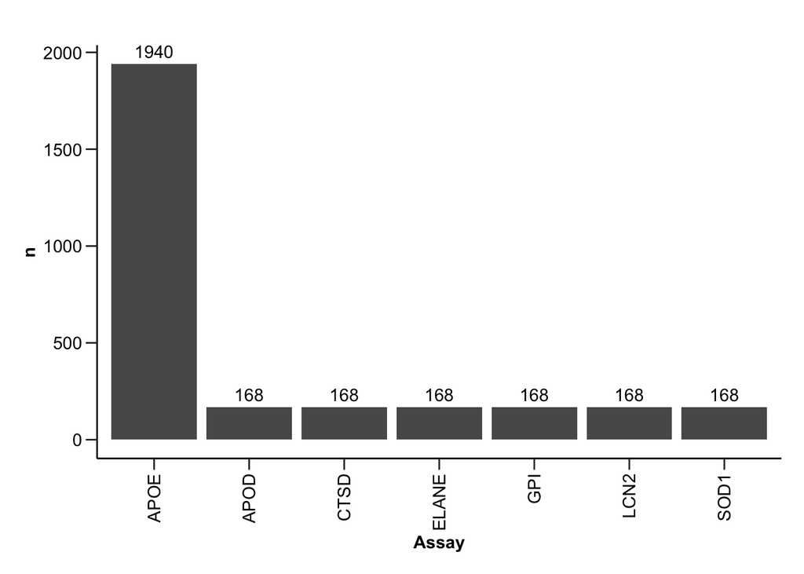

```r
data_step_2 |>
  group_by(Assay) |>
  count(AssayQC) |>
  filter(!AssayQC %in% c("NA", "PASS")) |>
  arrange(-n) |>
  ggplot(aes(fct_reorder(Assay,-n), n)) +
  geom_col() +
  geom_text(aes(label = n), vjust = -0.5) +
  theme_hpa(angle = T) +
  xlab("Assay")
```

```r
#ggsave(savepath("assay_qc.png"), h = 5, w = 10)

assays_high_warnings <-
  data_step_2 |>
  filter(!DAid %in% control_samples) |>
  group_by(Assay) |>
  mutate(n_total = n_distinct(DAid)) |>
  filter(AssayQC == "WARN") |>
  mutate(n = n_distinct(DAid)) |>
  ungroup() |>
  distinct(Assay, n, n_total) |>
  mutate(perc_warning = n / n_total) |> arrange(-n) |>
  filter(perc_warning > 0.5)
```

In the current dataset, the number of **assays with > 50% warnings is: 1**.

These assays will be excluded from further analysis.

```r
data_step_3 <-
  data_step_2 |>
  filter(!Assay %in% assays_high_warnings$Assay) |>
  select(-AssayQC)
```

# 5 Step 4: Outlier exploration

In this step, we use **PCA and UAMP to explore potential outliers in the dataset**. By visualizing the data in lower dimensions, we can identify samples that may behave differently from the rest and may need further investigation or exclusion.

```r
# Prepare data
input_data <-
  data_step_3 |>
  select(DAid, OlinkID, NPX) |>
  pivot_wider(names_from = "OlinkID", values_from = "NPX")

# Exclude protens below LOD in 50% of control measurements
exclude_proteins <-
  data_ht_lod |>
  filter(DAid %in% control_samples) |>
  mutate(under_LOD = ifelse(NPX < LOD, "Yes", "No")) |>
  group_by(Assay) |>
  count(under_LOD) |>
  filter(under_LOD == "Yes") |>
  ungroup() |>
  filter(n >= sum(!is.na(unique(data_ht_lod$Plate))))

input_data_filt <-
  data_step_3 |>
  filter(!Assay %in% exclude_proteins$Assay) |>
  select(DAid, OlinkID, NPX) |>
  pivot_wider(names_from = "OlinkID", values_from = "NPX")
```

## 5.1 PCA

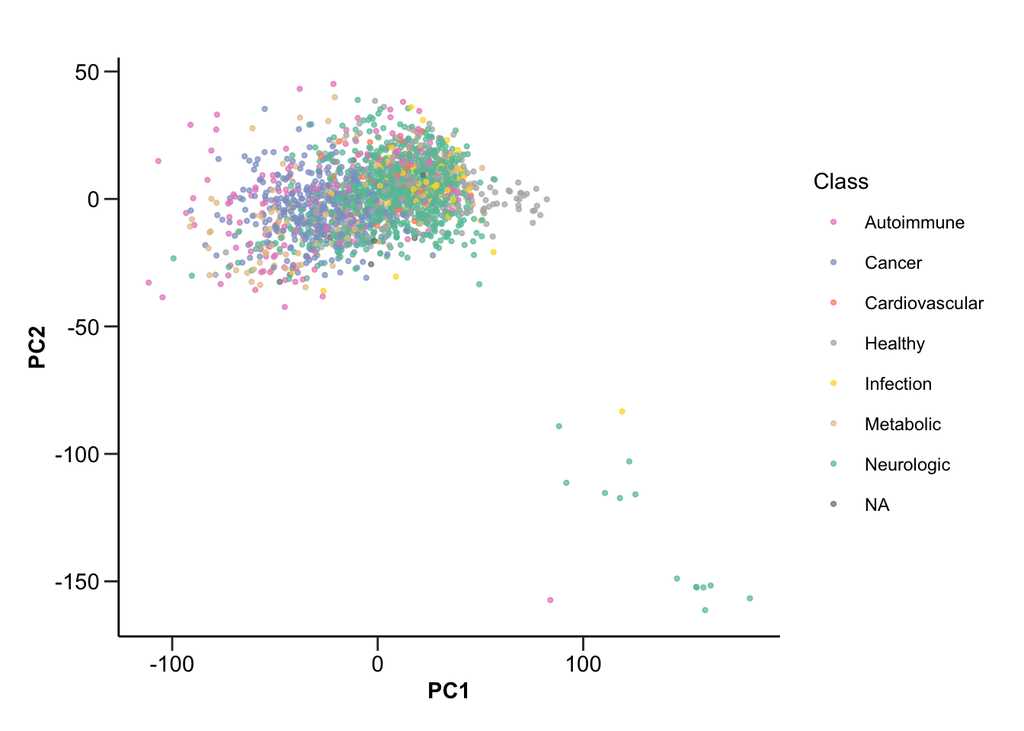

```r
pca_all_proteins <-
  do_pca(data = input_data,
          plots = F)

pca_all_proteins$pca_res |>
  rename(DAid = Sample) |>
  left_join(manifest, by = "DAid") |>
  mutate(Cohort = paste(Cohort, `PI - sample owner`, sep = "_")) |>
  ggplot(aes(PC1, PC2, color = Class)) +
  geom_point(alpha = 0.7, size = 0.8) +
  scale_color_manual(values = pal_class_2) +
  theme_hpa()
```

```r
#ggsave(savepath("pca.png"), h = 8, w = 8)

# ids <-
#   pca_all_proteins$pca_res  |>
#   filter(PC2 < -70)

# manifest |>
#   filter(DAid %in% ids$Sample) |>
#   select(`PI - sample owner`,  Cohort)
```

We identify the PCA outliers and remove them from the dataset.

```r
pca_outliers <-
  pca_all_proteins$pca_res |>
  filter(PC2 < -70) |>
  distinct(Sample)

data_step_4 <-
  data_step_3 |>
  filter(!DAid %in% pca_outliers$Sample)
```

**Figure 16**: PCA visualization based on all proteins and number of proteins detected per cohort, highlighting ourliers.

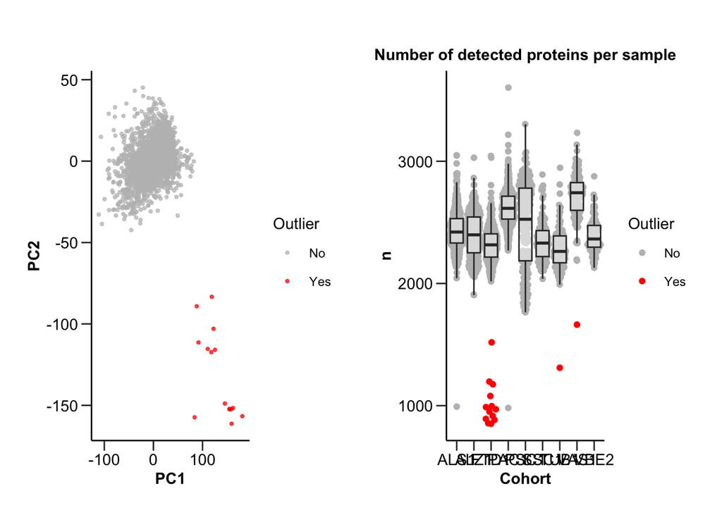

```r
plot_pca <-
  pca_all_proteins$pca_res |>
  rename(DAid = Sample) |>
  left_join(manifest, by = "DAid") |>
  mutate(Outlier = ifelse(DAid %in% pca_outliers$Sample, "Yes", "No")) |>
  ggplot(aes(PC1, PC2, color = Outlier)) +
  geom_point(alpha = 0.7, size = 0.8) +
  scale_color_manual(values = c("Yes" = "red", "No" = "grey")) +
  theme_hpa()

missing_per_sample <-
  data_ht_lod |>
  filter(SampleType == "SAMPLE") |>
  mutate(above_LOD = ifelse(NPX > LOD, "Yes", "No")) |>
  group_by(DAid) |>
  count(above_LOD) |>
  filter(above_LOD == "Yes") |>
  arrange(n)

plot_n <-
  missing_per_sample |>
  left_join(manifest, by = "DAid") |>
  filter(!Cohort %in% c("BDG2", "CTRL")) |>
  mutate(Outlier = ifelse(DAid %in% pca_outliers$Sample, "Yes", "No")) |>
  ggplot(aes(Cohort, n)) +
  geom_quasirandom(aes(color = Outlier)) +
  geom_boxplot(outlier.shape = NA, alpha = 0.5) +
  scale_color_manual(values = c("grey", "red")) +
  theme_hpa() +
  ggtitle("Number of detected proteins per sample")

plot_pca + plot_n
```

```r
#ggsave(savepath("pca_outliers.png"), h = 5, w = 12)
```

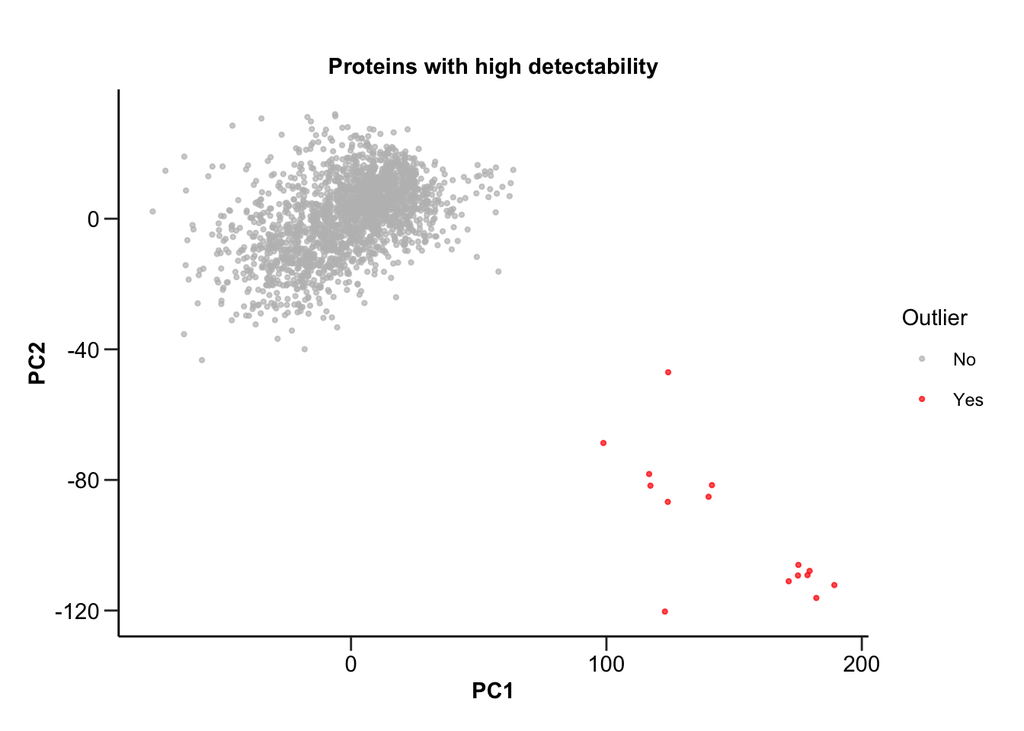

```r
pca_high_detectability <-
  do_pca(data = input_data_filt,
         plots = F)

pca_high_detectability$pca_res |>
  rename(DAid = Sample) |>
  left_join(manifest, by = "DAid") |>
  mutate(Outlier = ifelse(DAid %in% pca_outliers$Sample, "Yes", "No")) |>
  ggplot(aes(PC1, PC2, color = Outlier)) +
  geom_point(alpha = 0.7, size = 0.8) +
  scale_color_manual(values = c("grey", "red")) +
  theme_hpa() +
  ggtitle("Proteins with high detectability")
```

```r
#ggsave(savepath("pca_high_detectability.png"), h = 8, w = 8)
```

## 5.2 UMAP

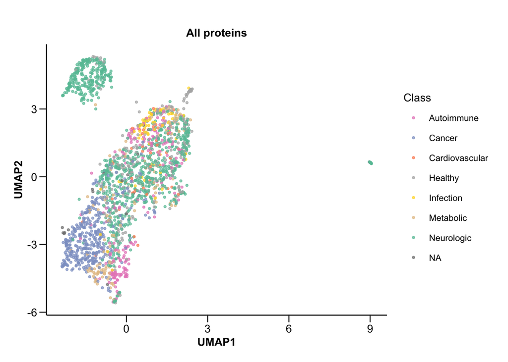

```r
umap_all_proteins <-
  do_umap(data = input_data,
          plots = F)

umap_all_proteins |>
  rename(DAid = Sample) |>
  left_join(manifest, by = "DAid") |>
  mutate(Cohort = paste(Cohort, `PI - sample owner`, sep = "_")) |>
  ggplot(aes(UMAP1, UMAP2, color = Class)) +
  geom_point(alpha = 0.7, size = 0.8) +
  scale_color_manual(values = pal_class_2) +
  theme_hpa() +
  ggtitle("All proteins")
```

```r
umap_outliers <-
  umap_all_proteins |>
  filter(UMAP2 > 5) |>
  rename(DAid = Sample) |>
  left_join(manifest, by = "DAid")
```

**Figure 19**: UMAP visualization based on all proteins and number of proteins detected per cohort, highlighting ourliers.

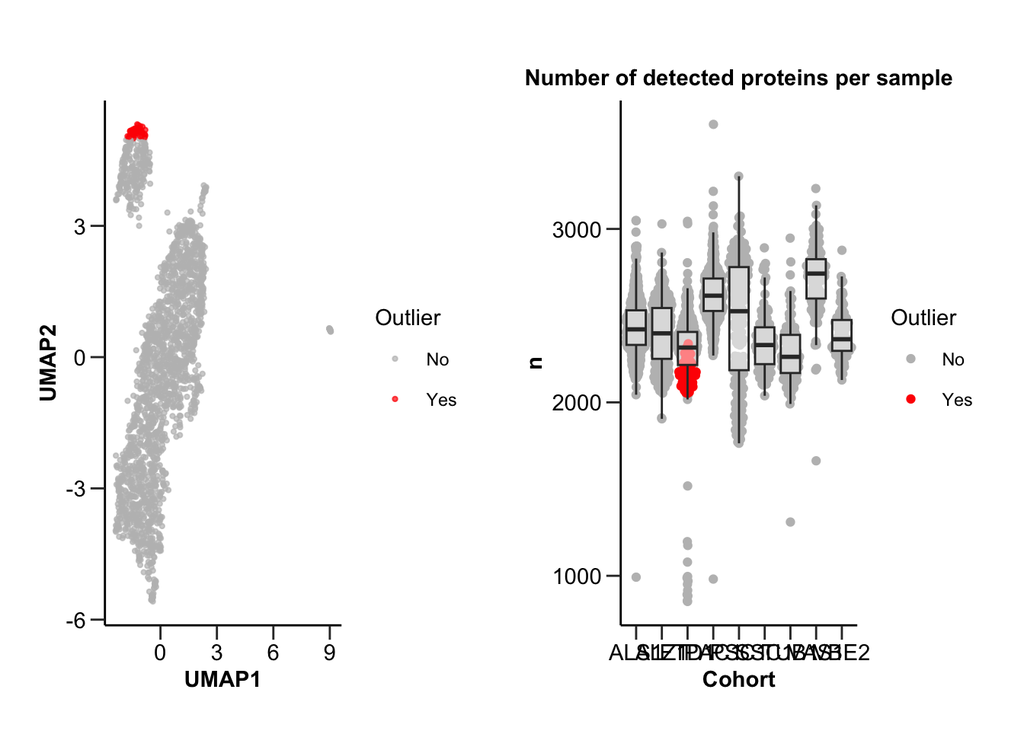

```r
plot_umap <-
  umap_all_proteins |>
  rename(DAid = Sample) |>
  left_join(manifest, by = "DAid") |>
  mutate(Outlier = ifelse(DAid %in% umap_outliers$DAid, "Yes", "No")) |>
  ggplot(aes(UMAP1, UMAP2, color = Outlier)) +
  geom_point(alpha = 0.7, size = 0.8) +
  scale_color_manual(values = c("Yes" = "red", "No" = "grey")) +
  theme_hpa()

plot_n <-
  missing_per_sample |>
  left_join(manifest, by = "DAid") |>
  filter(!Cohort %in% c("BDG2", "CTRL")) |>
  mutate(Outlier = ifelse(DAid %in% umap_outliers$DAid, "Yes", "No")) |>
  ggplot(aes(Cohort, n)) +
  geom_quasirandom(aes(color = Outlier)) +
  geom_boxplot(outlier.shape = NA, alpha = 0.5) +
  scale_color_manual(values = c("grey", "red")) +
  theme_hpa() +
  ggtitle("Number of detected proteins per sample")

plot_umap + plot_n
```

```r
#ggsave(savepath("umap_outliers.png"), h = 5, w = 12)
```

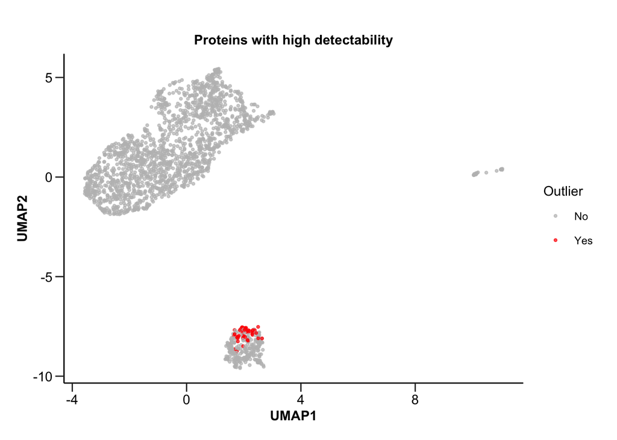

```r
umap_high_detectability <-
  do_umap(data = input_data_filt,
          plots = F)

umap_high_detectability |>
  rename(DAid = Sample) |>
  left_join(manifest, by = "DAid") |>
  mutate(Outlier = ifelse(DAid %in% umap_outliers$DAid, "Yes", "No")) |>
  ggplot(aes(UMAP1, UMAP2, color = Outlier)) +
  geom_point(alpha = 0.7, size = 0.8) +
  scale_color_manual(values = c("Yes" = "red", "No" = "grey")) +
  theme_hpa() +
  ggtitle("Proteins with high detectability")
```

```r
#ggsave(savepath("umap_high_detectability.png"), h = 8, w = 8)
```

```r
# Final check PSC1
#
# umap_high_detectability |>
#   rename(DAid = Sample) |>
#   left_join(manifest, by = "DAid") |>
#   mutate(Outlier = ifelse(DAid %in% umap_outliers$DAid, "Yes", "No")) |>
#   ggplot(aes(UMAP1, UMAP2, color = Outlier)) +
#   geom_point(alpha = 0.7, size = 0.8) +
#   scale_color_manual(values = c("Yes" = "red", "No" = "grey")) +
#   theme_hpa() +
#   ggtitle("Proteins with high detectability") +
#
# umap_high_detectability |>
#   rename(DAid = Sample) |>
#   left_join(manifest, by = "DAid") |>
#   ggplot(aes(UMAP1, UMAP2, color = Cohort)) +
#   geom_point(alpha = 0.7, size = 0.8) +
#   scale_fill_manual(values = brewer.pal(n = 11, name = "Set3")) +
#   theme_hpa() +
#   ggtitle("Proteins with high detectability")
#
#
# data_umap_highdetectability <-
#   data_step_5 |>
#   filter(!Assay %in% exclude_proteins$Assay)
#
# data_umap_highdetectability
#
# missing_per_sample <-
#   data_umap_highdetectability |>
#   mutate(above_LOD = ifelse(NPX > LOD, "Yes", "No")) |>
#   group_by(DAid) |>
#   count(above_LOD) |>
#   filter(above_LOD == "Yes") |>
#   arrange(n)
#
# #plot_n <-
# missing_per_sample |>
#   left_join(manifest) |>
#   filter(!Cohort %in% c("BDG2", "CTRL")) |>
#   mutate(Outlier_PCA = ifelse(DAid %in% pca_outliers$Sample, "Yes", "No")) |>
#   ggplot(aes(Cohort, n)) +
#   geom_quasirandom(aes(color = Outlier_PCA)) +
#   geom_boxplot(outlier.shape = NA, alpha = 0.5) +
#   scale_color_manual(values = c("grey", "red")) +
#   theme_hpa() +
#   ggtitle("Number of detected proteins per sample")
#
# new_umap_outliers <-
#   umap_high_detectability |>
#   filter(UMAP2 < 2.5, UMAP1 < -8)
#
# umap_high_detectability |>
#   rename(DAid = Sample) |>
#   left_join(manifest, by = "DAid") |>
#   mutate(Outlier = ifelse(DAid %in% new_umap_outliers$Sample, "Yes", "No")) |>
#   ggplot(aes(UMAP1, UMAP2, color = Outlier)) +
#   geom_point(alpha = 0.7, size = 0.8) +
#   scale_color_manual(values = c("Yes" = "red", "No" = "grey")) +
#   theme_hpa() +
#   ggtitle("Proteins with high detectability") +
#
# missing_per_sample |>
#   left_join(manifest) |>
#   filter(!Cohort %in% c("BDG2", "CTRL")) |>
#   mutate(Outlier_new_UMAP = ifelse(DAid %in% new_umap_outliers$Sample, "Yes", "No")) |>
#   ggplot(aes(Cohort, n)) +
#   geom_quasirandom(aes(color = Outlier_new_UMAP)) +
#   geom_boxplot(outlier.shape = NA, alpha = 0.5) +
#   scale_color_manual(values = c("grey", "red")) +
#   theme_hpa() +
#   ggtitle("Number of detected proteins per sample")
```

# 6 Final UMAP

Finally, we look at a UMAP of the final dataset after outlier exclusion.

**Figure 20**: UMAP visualization based on the final dataset.

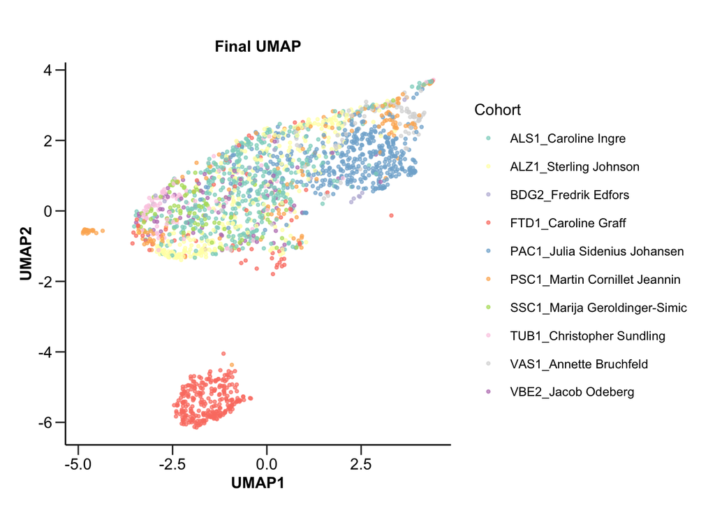

```r
umap_final <-
  do_umap(data = data_step_4,
          wide = F,
          plots = F)

umap_final |>
  rename(DAid = Sample) |>
  left_join(manifest, by = "DAid") |>
  mutate(Cohort = paste(Cohort, `PI - sample owner`, sep = "_")) |>
  ggplot(aes(UMAP1, UMAP2, color = Cohort)) +
  geom_point(alpha = 0.7, size = 0.8) +
  scale_color_manual(values = brewer.pal(n = 11, name = "Set3")) +
  theme_hpa() +
  ggtitle("Final UMAP")
```

```r
# umap_final |> filter(UMAP1 < -4.3) |>
#   rename(DAid = Sample) |>
#   left_join(manifest)
#
# umap_final |>
#   rename(DAid = Sample) |>
#   left_join(manifest, by = "DAid") |>
#   mutate(Disease = ifelse(Cohort == "PSC1", Disease, NA)) |>
#   ggplot(aes(UMAP1, UMAP2, color = Disease)) +
#   geom_point(alpha = 0.7, size = 0.8) +
#   #scale_color_manual(values = brewer.pal(n = 11, name = "Set3")) +
#   theme_hpa() +
#   ggtitle("Final UMAP")
```

# 7 Save final data

After completing the quality control and data curation steps, we **save the cleaned and processed dataset for sharing with collaborators and for further downstream analysis**. This final dataset is ready for use in subsequent phases of the project.

```r
curated_data <-
  data_step_4 |>
  select(-Count,    -ExtNPX, -PCNormalizedNPX) # Remove unnecessary columns

write_tsv(curated_data, file = "../data/final_data/data_phase2_batch4_curated_20250425.tsv")
```